# Landlocked Atlantic Salmon Winooski and Boquet River Redd Survey Quality Control Report

US Fish and Wildlife Service (contact: Jonah_Withers@fws.gov for issues)

Report run on: March 16, 2022

## Executive Summary

This document is intended to provide a coarse look at the data collected during Lake Champlain landlocked Atlantic salmon fall redd surveys. The document provides tables and visualizations intended to highlight any potential outliers.

## GPS IDs

Do counts of fish and redds all have associated GPS IDs?

Table 1. GPS IDs

|  | IDs | GPS.Points | Difference |
| --- | --- | --- | --- |
| Redds | 1041 | 1029 | 12 |
| Fish | 125 | 107 | 18 |

## Surface Water Temperature

Any outliers in terms of temperature measures collected at the start of each survey? Note that sometimes data are taken in degrees Celsius and need to be converted to degrees Fahrenheit. Temperatures in Celsius will usually be between 0-12 while temperatures in Fahrenheit should range from 32-60 in the fall.

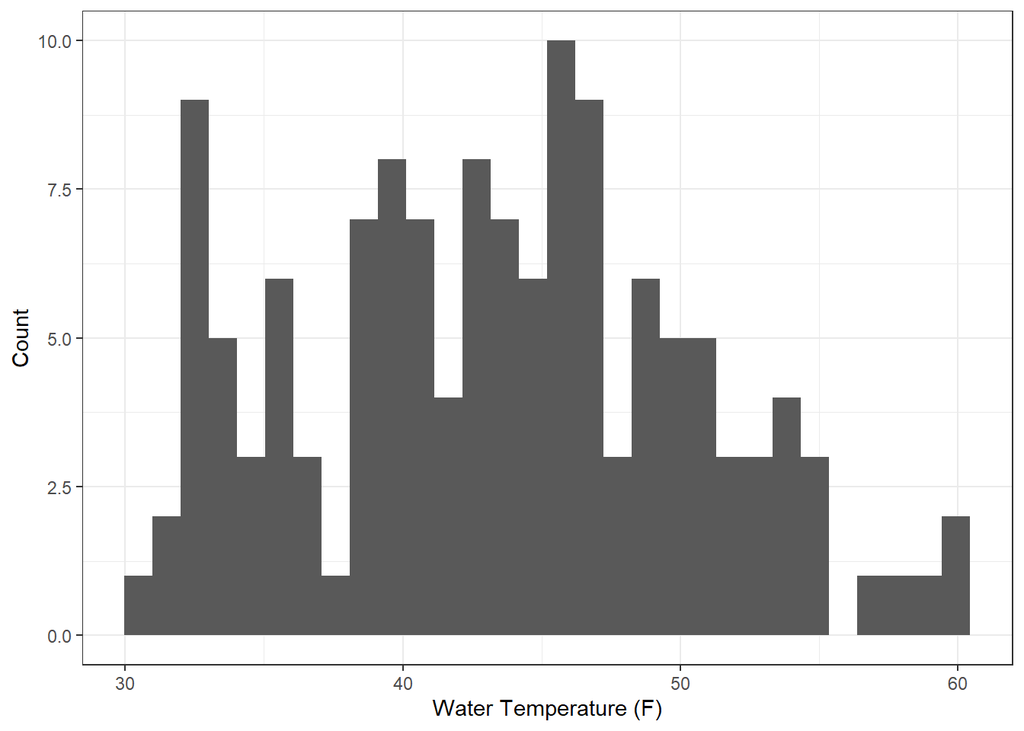

## Redd Distribution

Are the redds in locations we’d expect them to be in? Note that sometimes the GPS’s “jump” and waypoints might end up in a very different location than were the unit is.

[interactive chart not shown]

## Redd Size

Any outliers in terms of redd measurements?

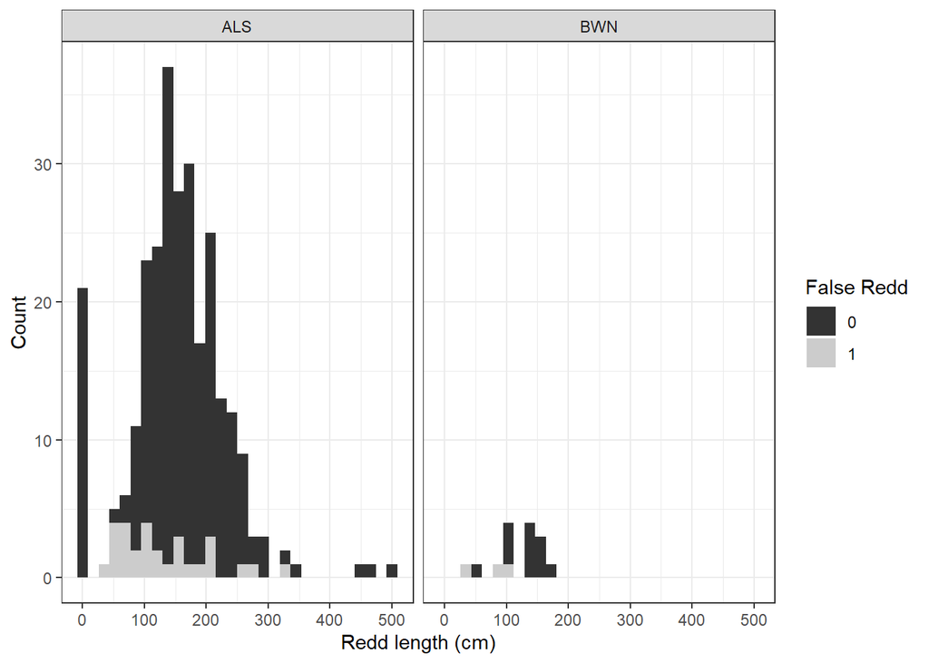

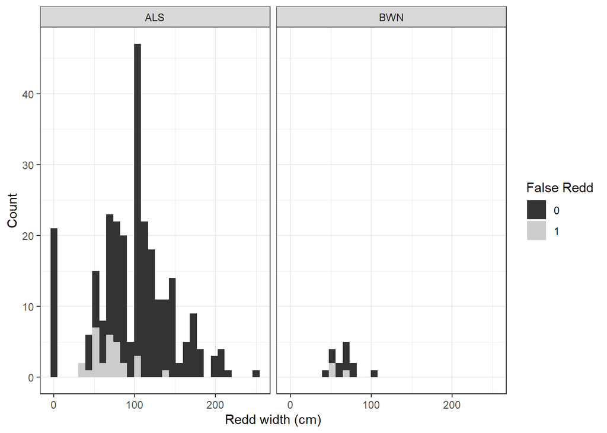

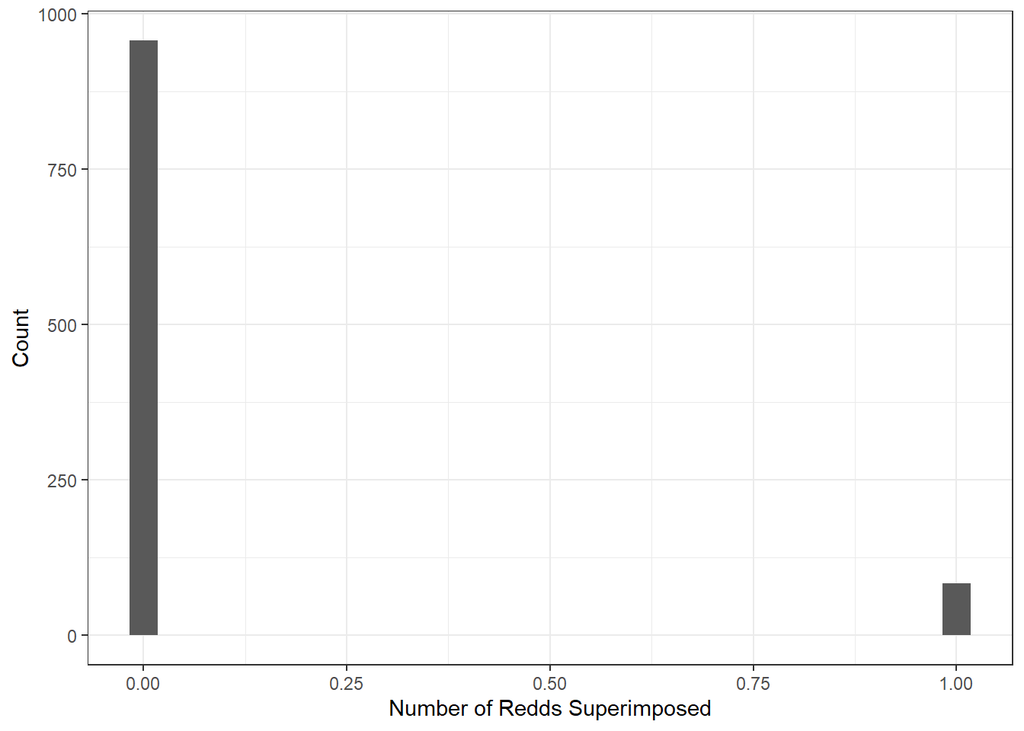

## Fish Size

Any outliers in terms of fish measurements?

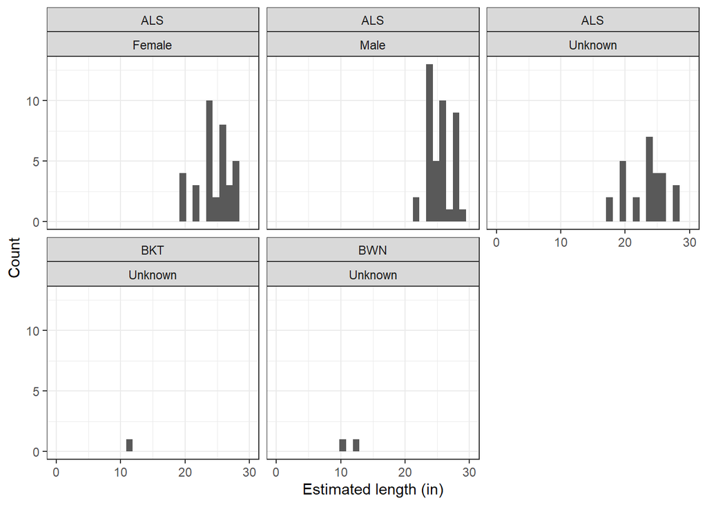

## Summary Tables

Summary tables of salmon and redd detected for each section and year. Any outliers?

Table 2. Winooski Redds by Site across Years

|  | HR-1 | JB-2 | MB-1 | MB-2 | WR-1 | WR-10 | WR-12 | WR-15 | WR-21 | WR-3 | WR-7 | WR-WD1 |
| --- | --- | --- | --- | --- | --- | --- | --- | --- | --- | --- | --- | --- |
| 2015 | 21.00 | 0.00 | 0.00 | 3.00 | 1.00 | 0.00 | 0.00 | 0.00 | 0.00 | 0.00 | 14.00 | 0.00 |
| 2016 | 9.00 | 1.00 | 3.00 | 0.00 | 0.00 | 0.00 | 7.00 | 5.00 | 5.00 | 0.00 | 4.00 | 0.00 |
| 2018 | 0.00 | 0.00 | 0.00 | 0.00 | 0.00 | 0.00 | 0.00 | 0.00 | 0.00 | 0.00 | 3.00 | 0.00 |
| 2019 | 0.00 | 0.00 | 0.00 | 0.00 | 0.00 | 0.00 | 1.00 | 0.00 | 0.00 | 0.00 | 0.00 | 0.00 |
| 2020 | 2.00 | 0.00 | 0.00 | 0.00 | 0.00 | 1.00 | 0.00 | 0.00 | 0.00 | 1.00 | 2.00 | 13.00 |
| 2021 | 0.00 | 0.00 | 0.00 | 0.00 | 0.00 | 0.00 | 0.00 | 0.00 | 0.00 | 0.00 | 0.00 | 14.00 |

Table 3. Boquet Redds by Site across Years

|  | BRNB01 | BRNB02 | BRNB03 | BRNB04 | BRMS05 |
| --- | --- | --- | --- | --- | --- |
| 2014 | 0.00 | 0.00 | 0.00 | 0.00 | 30 |
| 2015 | 0.00 | 2.00 | 0.00 | 0.00 | 198 |
| 2016 | 10.00 | 38.00 | 42.00 | 0.00 | 68 |
| 2017 | 1.00 | 5.00 | 20.00 | 6.00 | 9 |
| 2018 | 0.00 | 4.00 | 11.00 | 9.00 | 160 |
| 2019 | 0.00 | 2.00 | 1.00 | 0.00 | 1 |
| 2020 | 30.00 | 14.00 | 3.00 | 9.00 | 126 |
| 2021 | 24.00 | 17.00 | 0.00 | 0.00 | 40 |

Table 4. Winooski Salmon by Site across Years

|  | HR-1 | WR-7 | WR-WD1 |
| --- | --- | --- | --- |
| 2015 | 2.00 | 2.00 | 0.00 |
| 2021 | 0.00 | 0.00 | 2.00 |

Table 5. Boquet Salmon by Site across Years

|  | BRNB01 | BRNB02 | BRNB03 | BRNB04 | BRMS05 |
| --- | --- | --- | --- | --- | --- |
| 2018 | 0.00 | 0.00 | 1 | 3 | 3.00 |
| 2020 | 38.00 | 25.00 | 1 | 12 | 0.00 |
| 2021 | 19.00 | 6.00 | 2 | 1 | 4.00 |